# TIQ-TEST Experiments - Fall 2014

Alex Pinto

October 19, 2014

This is an R Markdown document for demonstrating the new tests and functionalities that are to be introduced in version 0.2 of tiq-test. No presentations have been made of this material yet.

If you are looking at this file and has no idea what is going on, it might help to review the previous entry in this series at [RPubs](http://rpubs.com/alexcpsec/tiq-test-Summer2014-2)

Please review our [github repository page](https://github.com/mlsecproject/tiq-test), report bugs and suggest features!

Adding the TIQ-TEST functions

```r
## Some limitations from not being an R package: Setting the Working directory
tiqtest.dir = file.path("..", "tiq-test")
current.dir = setwd(tiqtest.dir)
source("tiq-test.R")

## Setting the root data path to where it should be in this repo
.tiq.data.setRootPath(file.path(current.dir, "data"))
```

```
## INFO [2015-02-01 13:08:13 PST] pid=911 tiq.data.setRootPath: Setting path to '/Users/alexcp/src/tiq-test-Summer2014/data'
```

## Acessing the data using TIQ-TEST

We have roughly a month of data available on this public dataset, and this is still the same dataset as the Summer 2014 presentations:

```r
tiq.data.getAvailableDates("raw", "public_outbound")
```

```
##  [1] "20140615" "20140616" "20140617" "20140618" "20140619" "20140620"
##  [7] "20140621" "20140622" "20140623" "20140624" "20140625" "20140626"
## [13] "20140627" "20140628" "20140629" "20140630" "20140701" "20140702"
## [19] "20140703" "20140704" "20140705" "20140706" "20140707" "20140708"
## [25] "20140709" "20140710" "20140711" "20140712" "20140713" "20140714"
## [31] "20140715"
```

## Aging Test

The aging test will try to identify how long a specific indicator has lived in a threat feed. As with other tests, like the population and novelty, you are able to measure this information on aggregate of all your subgroups or separately.

Here is it run against the whole dataset on the Outbound indicators, as they are separated out on subgroups:

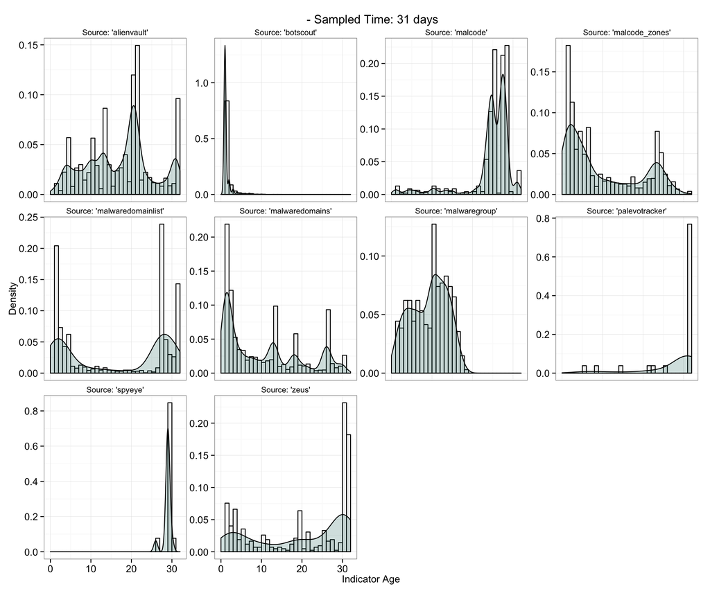

```r
outbound.aging = tiq.test.agingTest("public_outbound", "20140615", "20140715")
tiq.test.plotAgingTest(outbound.aging)
```

You can also look at it as whole thing, as to evaluate the aging of your whole TI repository:

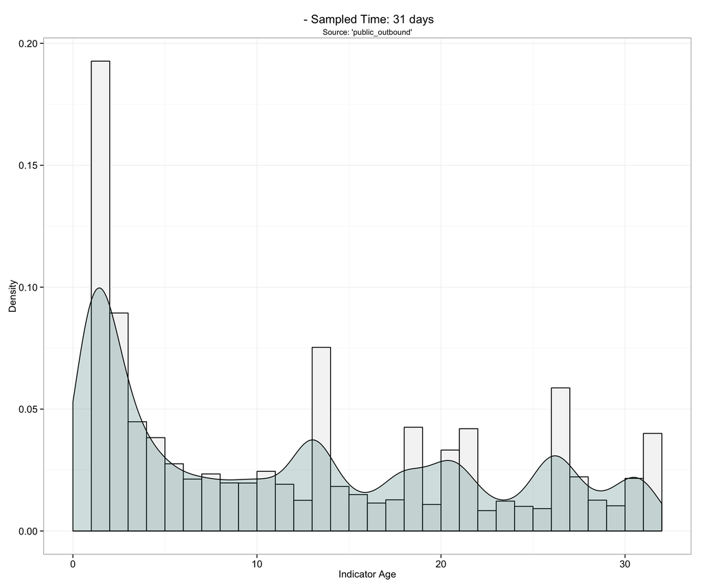

```r
outbound.full.aging = tiq.test.agingTest("public_outbound", "20140615", "20140715",
                                         split.ti=FALSE)
tiq.test.plotAgingTest(outbound.full.aging)
```

Here is it run against the whole dataset on the Inbound indicators. It is interesting to observe how they have different distributions because of the different ways of collecting the data:

```r
inbound.aging = tiq.test.agingTest("public_inbound", "20140615", "20140715")
```

```
## WARN [2015-02-01 13:09:00 PST] pid=911 tiq.data.loadTI: path '/Users/alexcp/src/tiq-test-Summer2014/data/enriched/public_inbound/20140621.csv.gz' is invalid. No data available on date '20140621'.
```

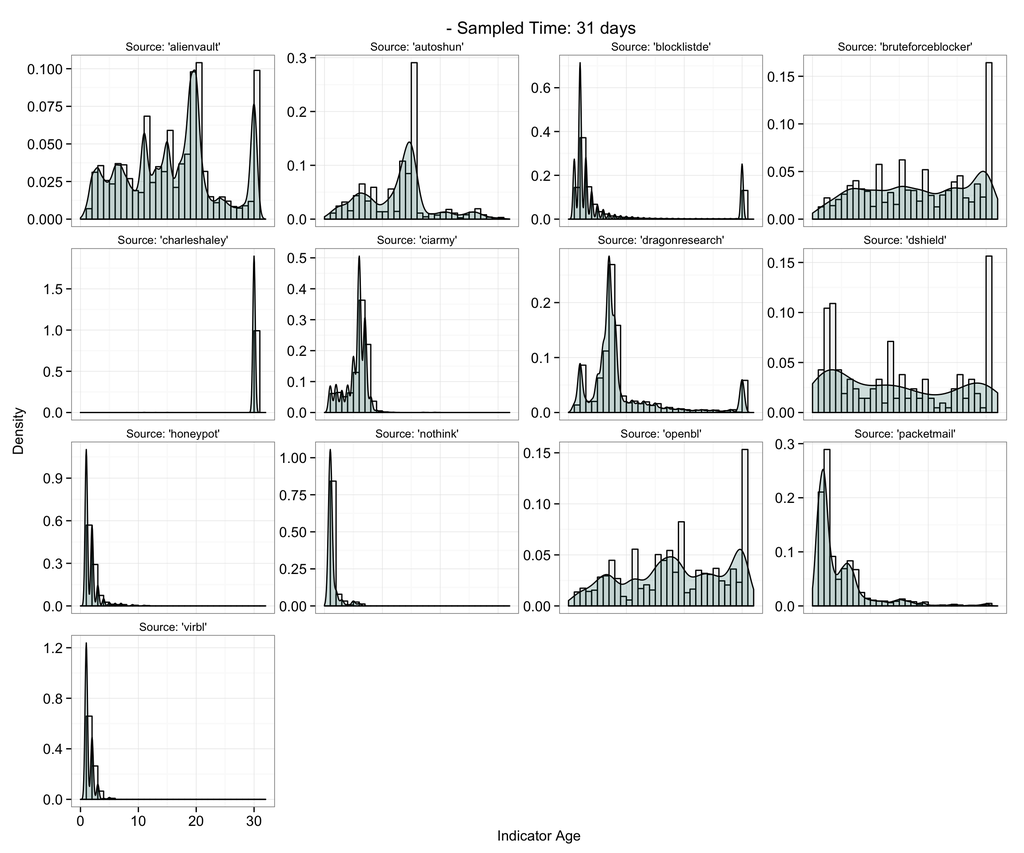

```r
tiq.test.plotAgingTest(inbound.aging)
```

That’s all for now, folks! Feel free to suggest new tests and experiments!